# ISLR_Lab2

## Basic R

```r
x <- rnorm(100)
y <- rnorm(100)

# create pdf of plot
pdf("Figure1_scatter.pdf")
plot(x,y)
dev.off() # signifies done plotting
```

**Contour plots** represent 3D data, like a topographical map

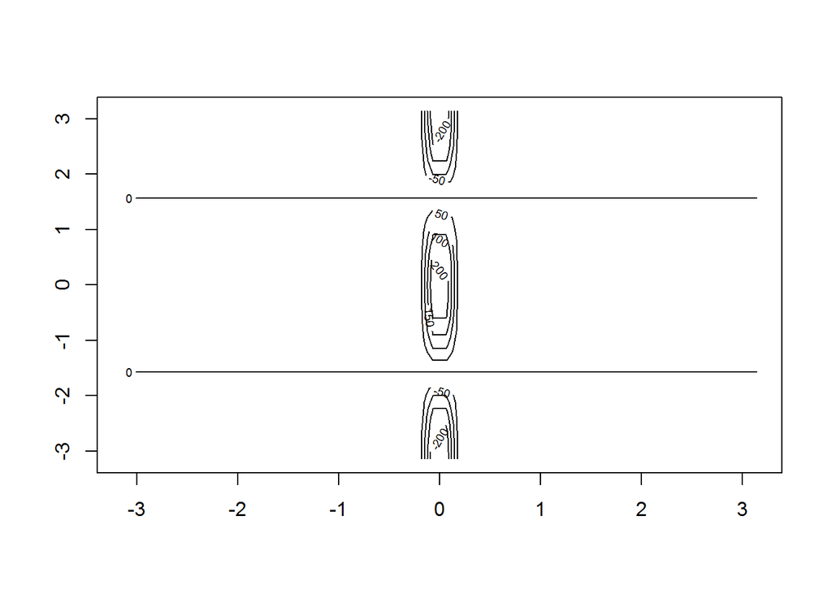

```r
x <- seq(-pi,pi,length=50)
y <- x

# outer product of arrays = outer(vector1,vector2,function to perform on outer products)
f <- outer(x,y, function(x,y) cos(y)/(1*x^2))

# plot contour(x,y,z)
contour(x,y,f)
```

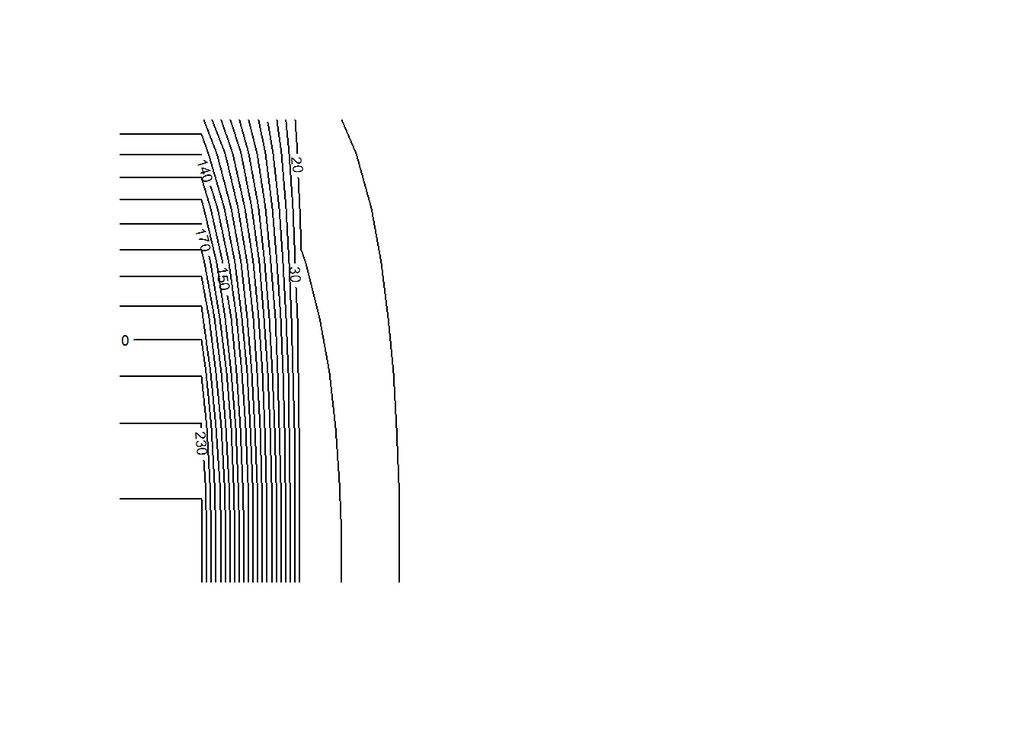

```r
plot.new()
contour(x,y,f, nlevels = 45, add = T)
```

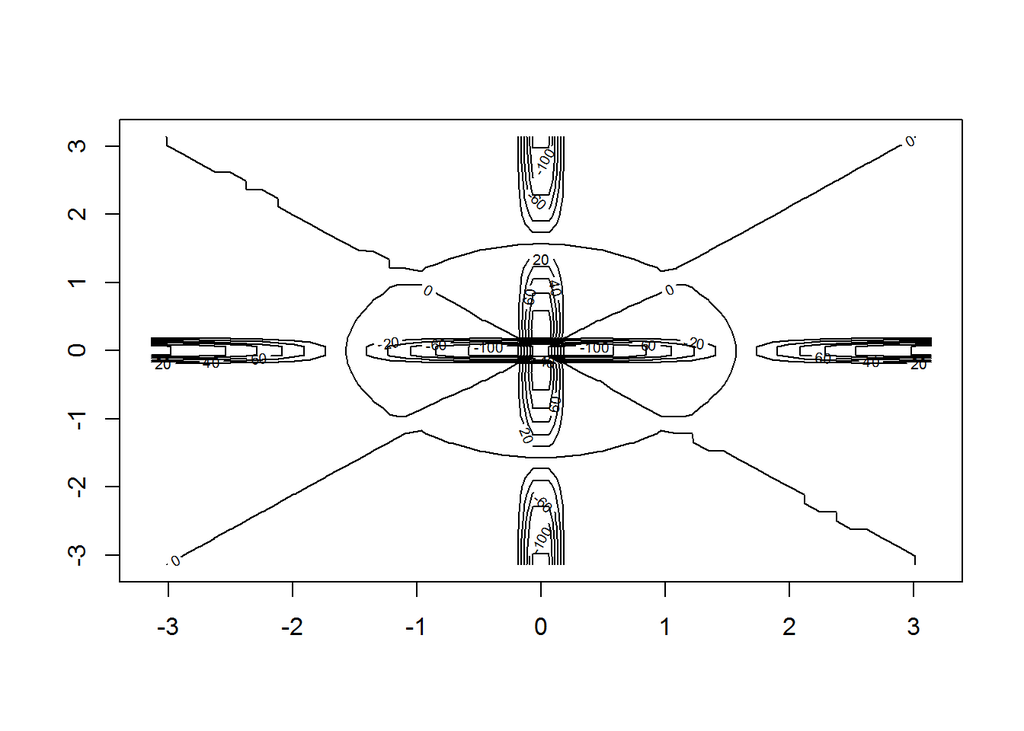

```r
#plot.new()
f2 <- (f-t(f))/2
contour(x,y,f2, nlevels = 15)
```

Can also develop a similar plot, a **heatmap**, with color-coded values for `z`.

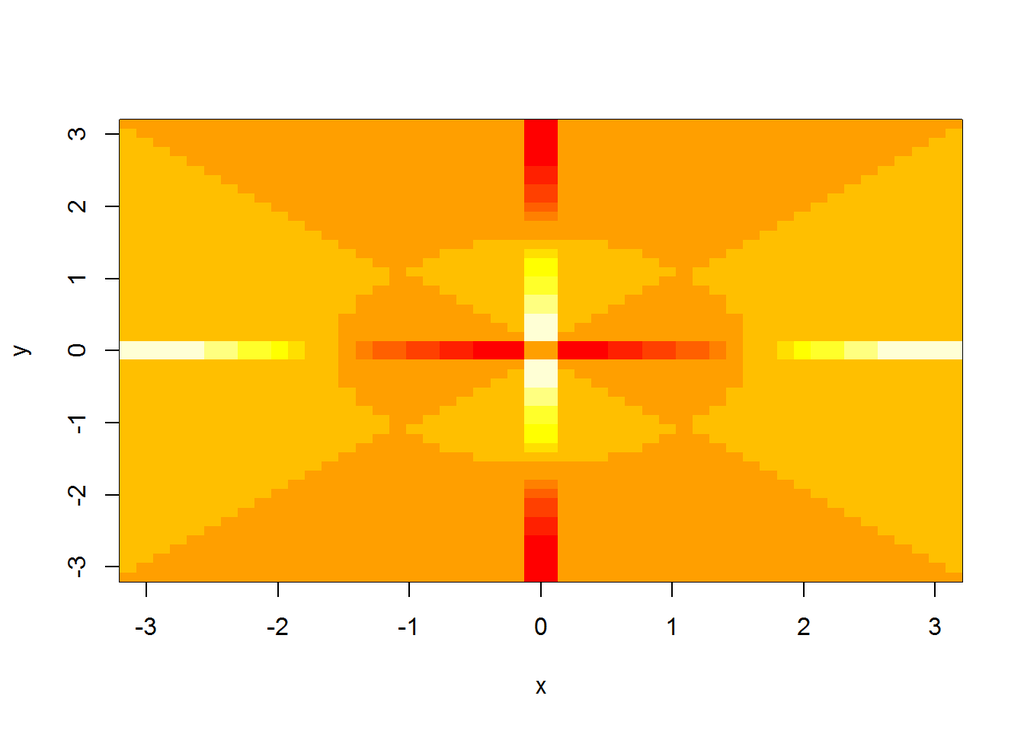

```r
image(x,y,f2)
```

Can also create 3D plots with `persp()`, via its arguments `theta`, `phi`, which control angles at which plot is viewed

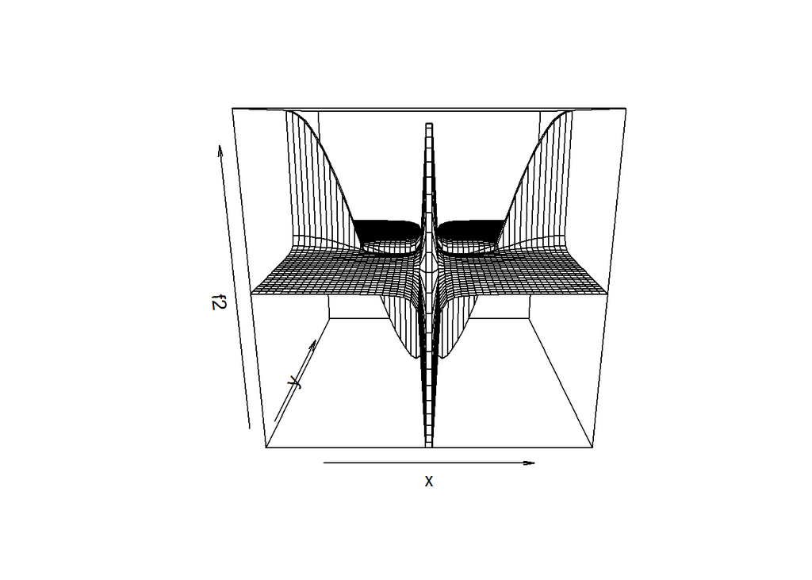

```r
persp(x,y,f2)
```

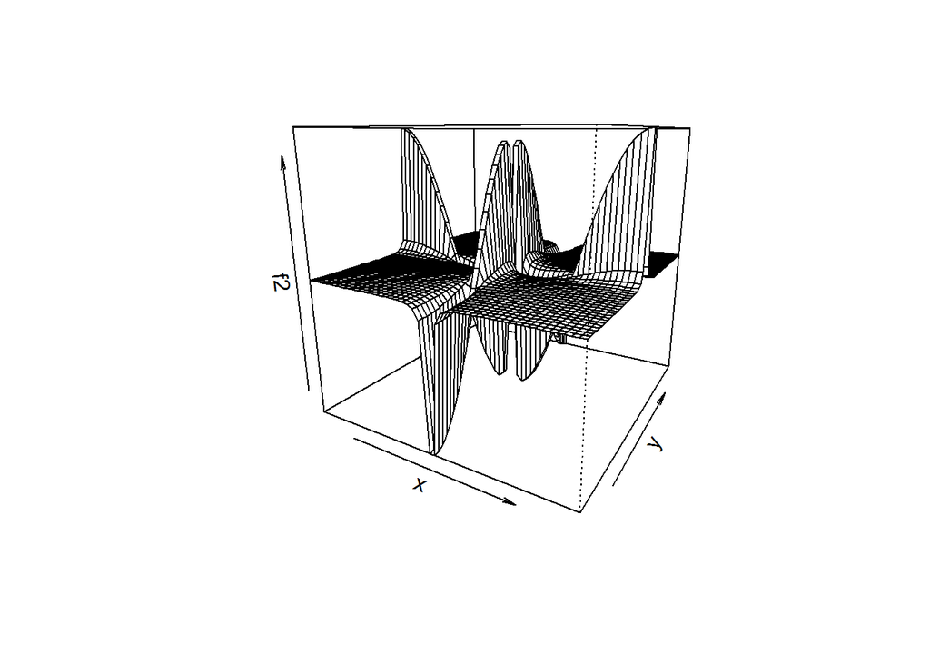

```r
persp(x,y,f2,theta=30)
```

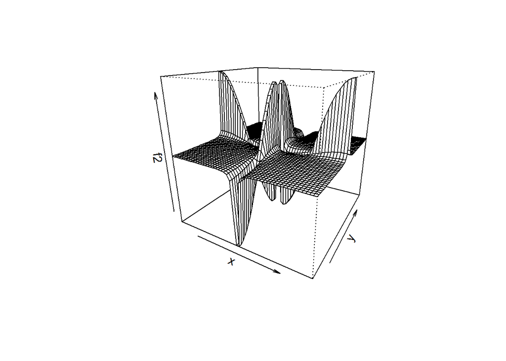

```r
persp(x,y,f2,theta=30,phi=20)
```

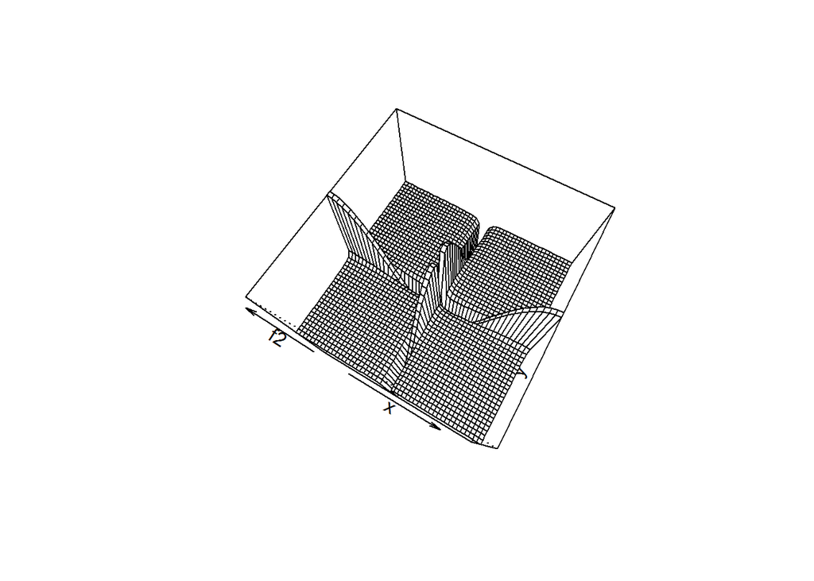

```r
persp(x,y,f2,theta=30,phi=70)
```

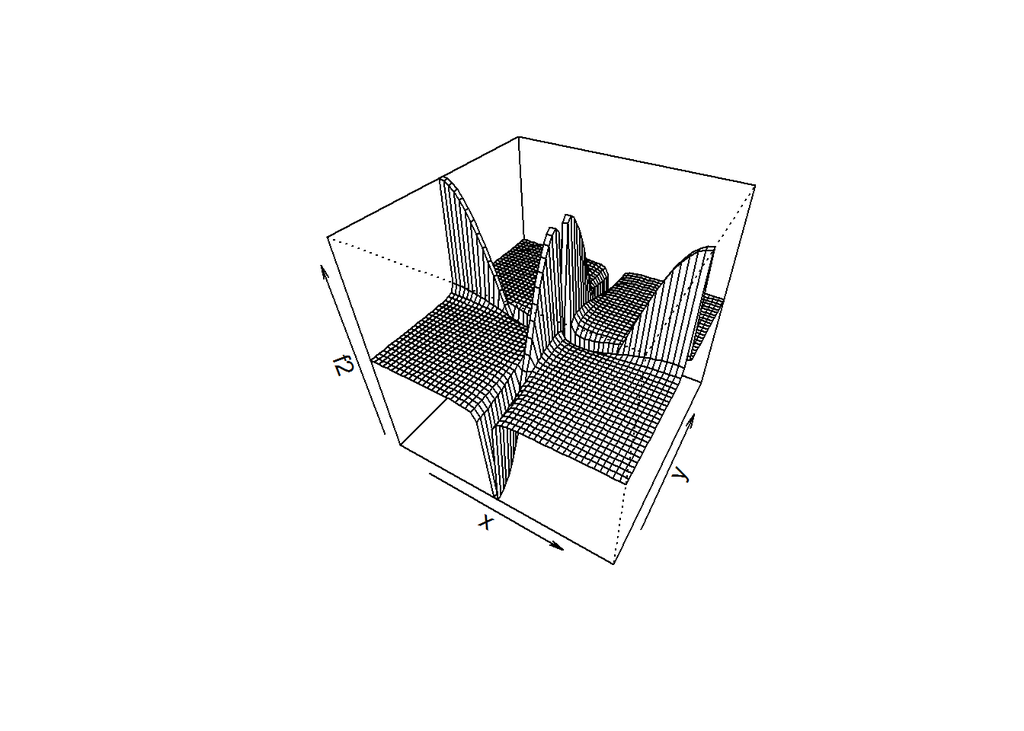

```r
persp(x,y,f2,theta=30,phi=40)
```

Here’s some more plots

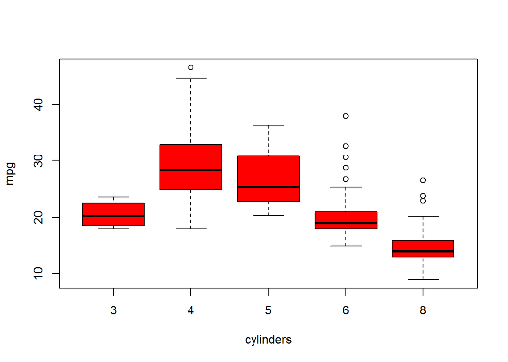

```r
library(ISLR)
fix(Auto) # view data in another window as spreadsheet

attach(Auto) # don't have to use '$' operator for accessing cols
cylinders <- as.factor(cylinders)
plot(cylinders, mpg, col="red", xlab="cylinders", ylab="mpg")
```

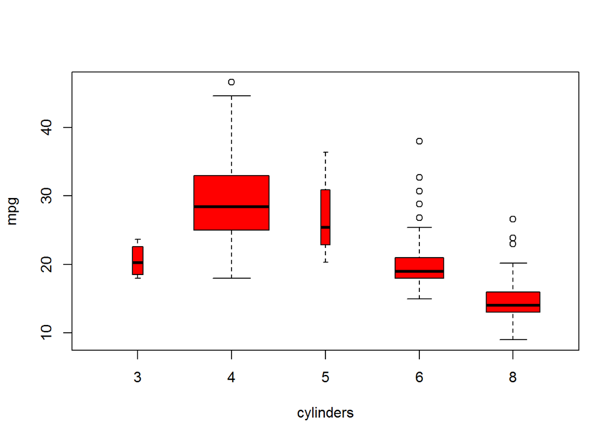

```r
plot(cylinders, mpg, col="red", varwidth=T, xlab="cylinders", ylab="mpg")
```

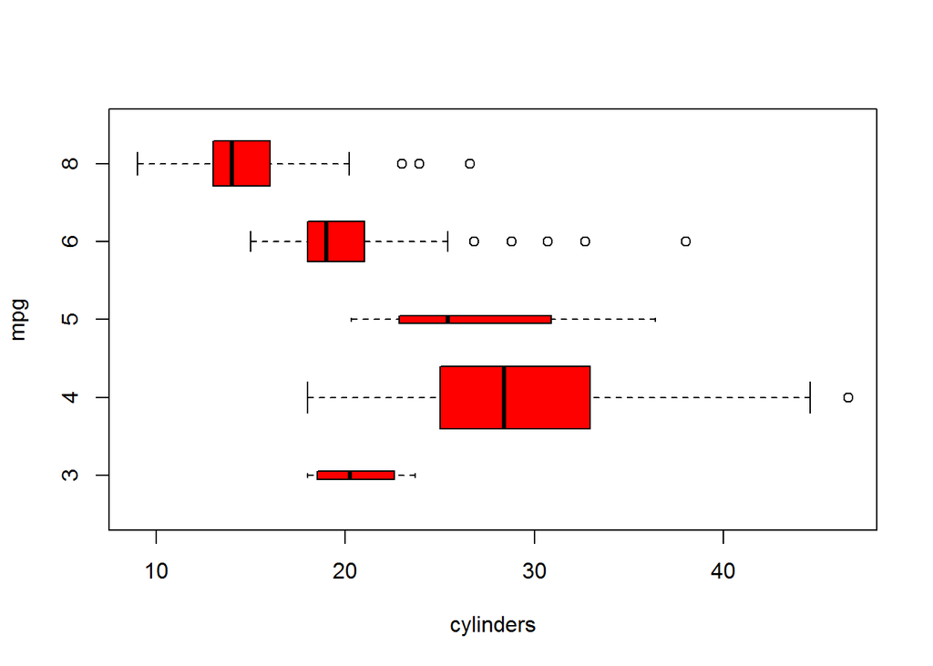

```r
plot(cylinders, mpg, col="red", varwidth=T, xlab="cylinders", ylab="mpg", horizontal=T) # flip previous plot
```

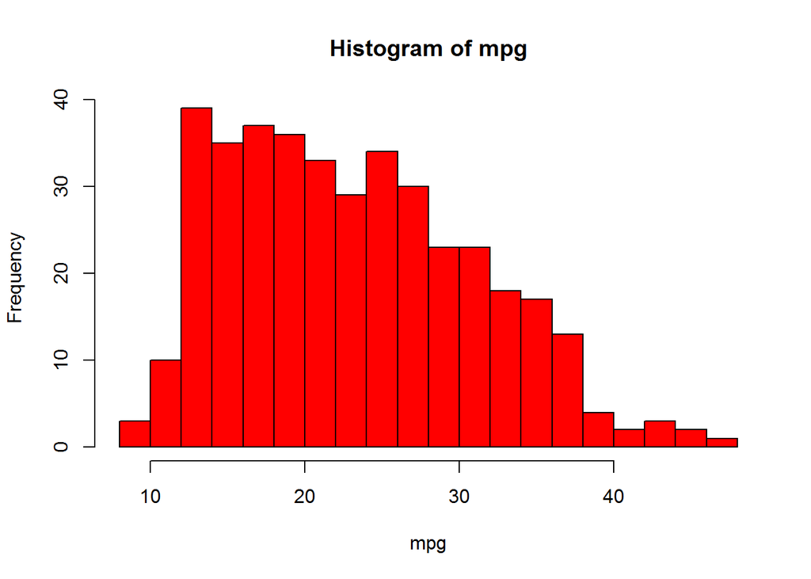

```r
hist(mpg,col=2,breaks=15) # col=2 same as red
```

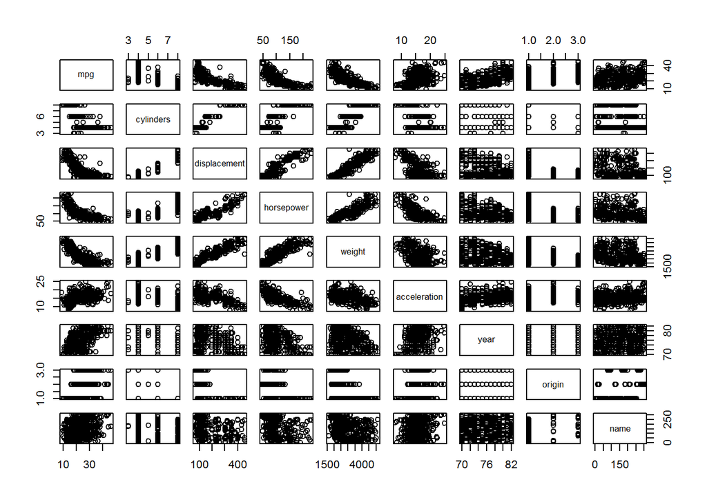

```r
# create scatterplot matrix
pairs(Auto)
```

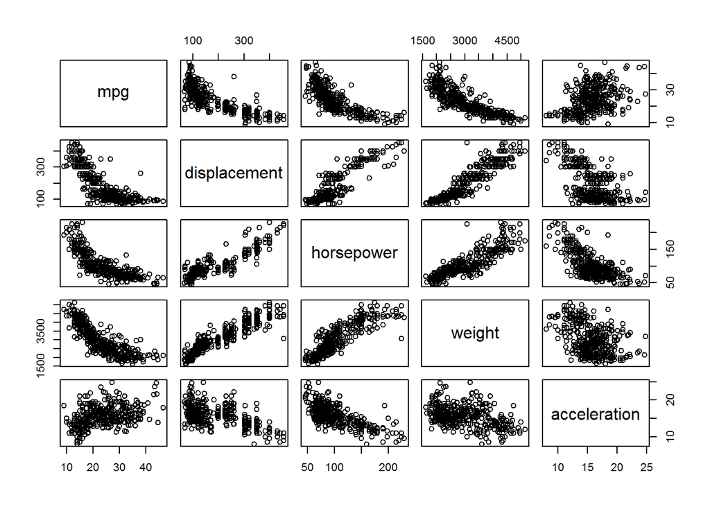

```r
# create smaller scatterplot matrix
pairs(~ mpg+displacement+horsepower+weight+acceleration, Auto)
```

`identify(x,y,variable)` provides useful interactive method for IDing values for a particular variable for on a plot. Clicking on a given point in the plot causes R to print the value of the variable of interest. Right-clicking on the plot will exit `identify()` function (control-click on a Mac). The numbers printed under `identify()` correspond to the rows for the selected points

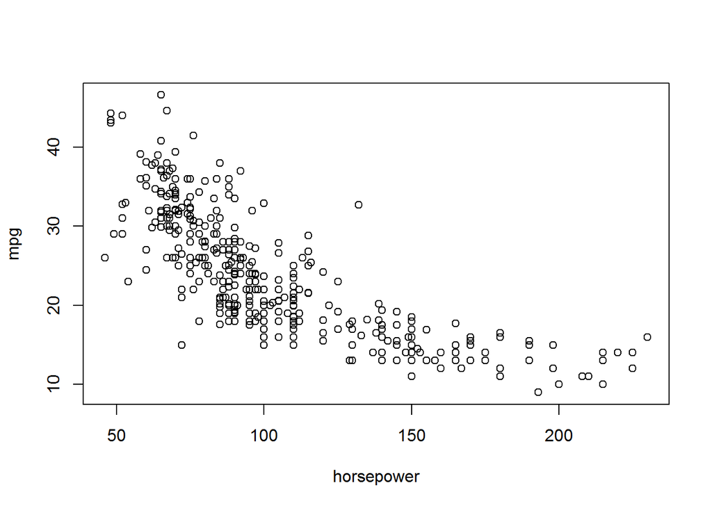

```
## integer(0)
```

```r
plot(horsepower,mpg)
identify(horsepower,mpg,name)
```